# Political violence

## Political violence as contention

- Although we’ve mostly focused on non-violent social movements, violent action is also part of “contentious politics”

# Lethal Conflict

**Forms of violent contention:**

- Riots and armed protests
- Terrorism
- Civil War
- Revolution

## Lethal Conflict

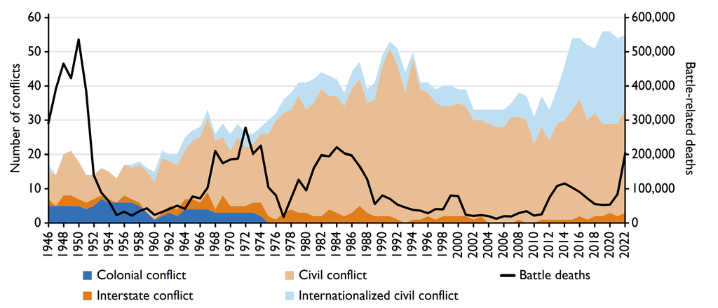

## Violence in politics

## Violence in politics

- Narodnaya Volya, considered the first “modern terrorist group”, viewed themselves as a political party

[figure not shown]

## Violence in politics

- Militant non-state actors often find themselves in a position to govern: Hamas, ISIS, the Tamil Tigers etc. have all had real or de facto states at some point

[figure not shown]

## Violence in politics

- Political parties and movement organizations sometimes turn to violent tactics, or maintain militant and political wings simultaneously.

[figure not shown]

# Distinguishing features

Many of the dynamics here are the same, but there are some differences of degree at least:

1. High stakes
2. High barriers to participation
3. High levels of institutionalization

# Potential Explanations

## Grievances and ideology

- Common, but contested, explanations for violence.
- Many participants are psychologically “typical”.

## Grievances and ideology

- Participants say they’re motivated by beliefs.
- Ideology may create a permission structure for violence.

…

[figure not shown]

## Hobbesian violence

- “Fog of war”
- Weakened internal and external controls.
- Opportunism

## Hobbesian violence

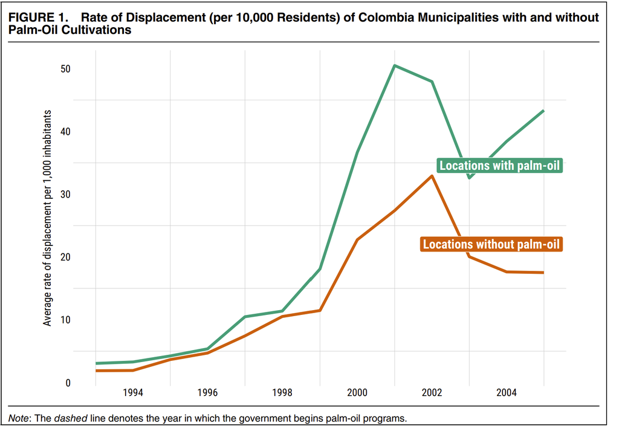

(Tellez 2022)

## Regime Type

- Regime type is correlated with civil war and terrorism

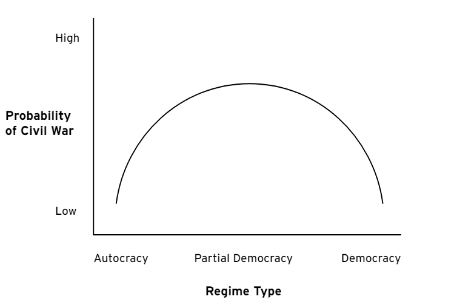

## Regime type

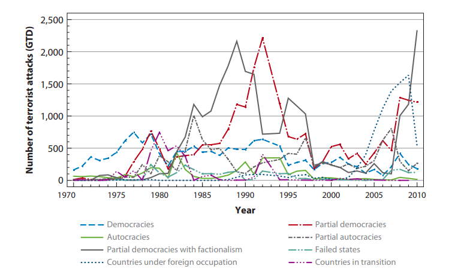

(Chenoweth 2013)

## Resources

- External supporters may encourage violence
- The presence of “lootable” resources can lead groups to *prefer* a smaller coalition

## Resources

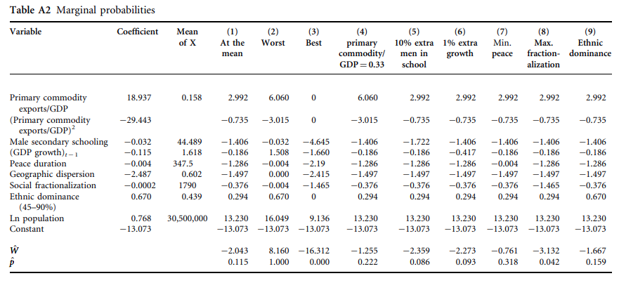

(Collier and Hoeffler 2004)

## Group Dynamics

- “Outbidding” theories: groups compete for members and support
- Committed recruits often demand some kind of activity.

## Group dynamics

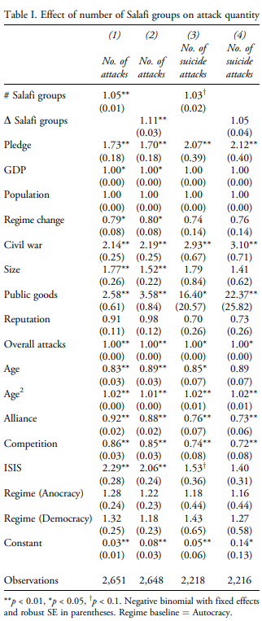

(Farrell 2020)

Chenoweth, Erica. 2013. “Terrorism and Democracy.” *Annual Review of Political Science* 16 (1): 355–78.

Collier, Paul, and Anke Hoeffler. 2004. “Greed and Grievance in Civil War.” *Oxford Economic Papers* 56 (4): 563–95.

Farrell, Megan. 2020. “The Logic of Transnational Outbidding: Pledging Allegiance and the Escalation of Violence.” *Journal of Peace Research* 57 (3): 437–51.

Tellez, Juan Fernando. 2022. “Land, Opportunism, and Displacement in Civil Wars: Evidence from Colombia.” *American Political Science Review* 116 (2): 403–18.